# Bayesian Data Analysis in a Nutshell

Introduction to Probabilistic Language

Felipe Ferrão

University of Florida – June, 2021

In this hands-on, we consider situations where the predicted variable is metric, and the single predictor is also metric. For example, predicting a person’s weight from their height, or predicting their blood pressure from their weight. For that, the relationship between the predicted variable, *y*, and predictor, *x*, is a simple linear model that have normally distributed residual randomness in y. This model is often referred to as **simple linear regression**. In this scenario, we have 3 main objectives:

- We will explore a regression example using a Frequentist approach
- Check how we can approach it in a Bayesian Context
- Present a short tutorial on how to fit Bayesian Regression models using MCMC-based approaches.

# Theory

## Introduction

The simplest regression models is linear with a single predictor:

$$y=\beta_0+\beta_1x+e$$

- The terms $\beta_0$ and $\beta_1$, are the intercept and slope of the model, respectively.
- Intercept is the point at which the line crosses the y axis at x = 0. It is also the mean, specifically the conditional mean, of y for individuals with values of 0 on x.
- The slope expresses the relationship between y and x. Positive slope values indicate that larger values of x are associated with correspondingly larger values of y, while negative slopes mean that larger x values are associated with smaller y values. Holding everything else constant, larger values of slope (positive or negative) indicate a stronger linear relationship between y and x.
- Error represents the random error inherent in any statistical model, including regression. It expresses the fact that for any individual, the model will not generally provide a perfect predicted value of y.

This same model can be written using different notations. For example:

- **Matrix notation:** $y=X\beta+e$, where $X_{N\times K}$ is matrix of predictors with dimension N (sample size) by K (number os predictiors).
- **Probabilistically**: $y_i \sim N(\beta_0 + \beta_1x_i, \sigma^2)$, where the The parameter $\sigma^2$ represents the variability with which the outcomes deviate from their predictions based on the model. This nomenclature is *more common* in Bayesian description.

## Regression Models in a Frequentist Framework

In all real-world contexts, the population is unavailable to the researcher. Therefore, $\beta_0$ and $\beta_1$ must be estimated using sample data taken from the population. The statistical literature describes several methods for obtaining estimated values of the regression model parameters given a set of x and y.

**Ordinary Least Squares (OLS)**

- By far, OLS is the most popular and widely used approach for inference.
- The goal of OLS is to minimize the sum of the squared differences (RSS) between the observed values of y and the model predicted values of y across the sample.

$$\hat{\beta} = (X'X)^{-1} X'y$$

**Maximum Likelihood**

- If the errors from the linear model are independent and normally distributed, then the OLS is also the maximum likelihood estimate. Technically, maximizing the likelihood requires minimizing the sum of squared residuals.
- The likelihood function in a regression model is defined as the probability density of the data given the parameters and predictors.

$$p(y|\beta_0,\beta_1,\sigma^2,x) = \prod^n_{i=1} N(y_i|\beta_0+\beta_1x_i,\sigma^2)$$

### Example

- Simulated a fake data
- Fitted a model using linear algebra and the `lm` funtion in `R`

**R codes**

```r
# Simulation
set.seed(125)
x=1:20
n=length(x)
a= 0.2
b=0.3
sigma=0.5
y = a +b*x + sigma*rnorm(x)

# OLS
X = as.matrix(data.frame(1,x))
solve( t(X)%*%X )%*%t(X)%*%y

# Using the lm function
fm = lm(y~x)
summary(fm)
```

## Regression in a Bayesian Context

**Motivation**

- Incorporating prior information
- Bayesian inference expresses uncertainty using probability
- OLS tends to overfit when **p** is large, Bayes’ use of prior tends to make it more conservative.

**Mathematically**

$$p(\beta_0, \beta_1, \sigma^2 \mid y) = \dfrac{p(y \mid \beta_0,\beta_1, \sigma^2) \times p(\beta_0,\beta_1,\sigma^2)}{p(y)}$$

- $p(\beta_0, \beta_1\sigma^2 \mid y)$ : posterior distribution
- $p(y \mid \beta_0,\beta_1, \sigma^2)$: likelihood
- $p(\beta_0,\beta_1,\sigma^2)$: prior for the parameters
- $p(y)$: evidence

**Graphical Representation**

From the diagram, it is easy to see that the response is modeled as a normal distribution with mean ($\mu_i = \beta_0 + \beta_1X_i$) and standard deviation $\sigma^2$. To make Bayesian estimation possible, we need to assign prior distributions to all model parameters, thus making our assumptions about the parameters explicit. We need to specify an appropriate likelihood, which is the normal likelihood function. The likelihood component is the part that incorporates the data. Bayes’ rule can be applied in order to update the priors to the posterior distributions, which reﬂect the distribution of credible parameter values taken into account the data.

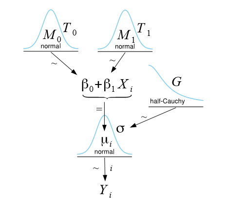

Probabilistic formulation of the simple linear regression model

**Why we need to use MCMC for Simple Regression**

To answers this question, let’s look first to a normal probability density function.

$$p(y\mid\mu,\sigma) = \dfrac{1}{\sigma\sqrt{2\pi}} e^{-\frac{(x-\mu)^2}{2\sigma^2} }$$

To get an intuition for the normal distribution as a likelihood function, we will consider the same example presented by [Kruschke (2014)](https://www.elsevier.com/books/doing-bayesian-data-analysis/kruschke/978-0-12-405888-0), where three data values y1 = 85, y2 = 100, and y3 = 115 were considered. The Figure shows $p(D\mid \mu, \sigma )$ for different values of $\mu$ and $\sigma$ . As you can see, there are values of that make the data most probable, but others no. The question is, given the data, how should we allocate credibility to combinations of $\mu$ and $\sigma$?

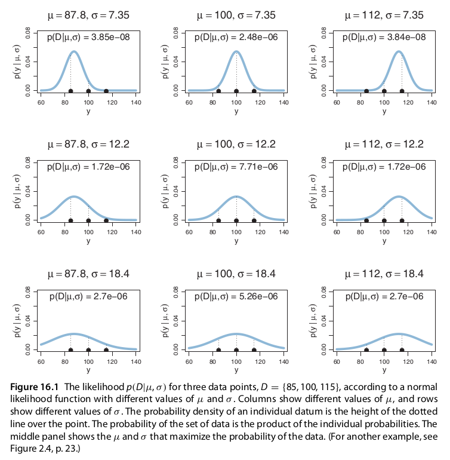

The answer this question we need to use the Bayes’ rule and solve the follow equation:

$$p(\mu,\sigma \mid D) = \dfrac{p(D\mid\mu,\sigma) \ p(\mu,\sigma)}{\iint d\mu\ d\sigma\ p(D\mid\mu,\sigma)\ p(\mu,\sigma)}$$

The reason for this analytic intractability stems essentially from difficulty in computing the denominator of the Bayes’ rule application. In the case of the posterior distribution expressed by the equation, the denominator requires that we integrate the numerator over the bivariate prior distribution for $\mu$ and $\sigma$ which is to say, we have to compute this two-dimensional integral. In the case of simple regression this is a three-dimensional integral that involves $\beta_0$, $\beta_1$ and $\sigma^2$. Now, image in case of multiple regressions?

Some solutions for that:

- Conjugate prior distributions. Be prepared for mathematics. [Gelman et al., (2013)](http://www.stat.columbia.edu/~gelman/book/) and [Hoff (2009)](https://www.amazon.com/Bayesian-Statistical-Methods-Springer-Statistics/dp/0387922997) are both good books with intuitive examples
- Program your own MCMC. Be prepared$^2$ !!
- Probabilistic programming language that is a system that automatically builds MCMC samples for complex models. Best suited for users who do not want to delve into mathematical details. Below, some examples of programming languages:
  - [BUGS](https://www.mrc-bsu.cam.ac.uk/software/bugs/)
  - [JAGS](https://mcmc-jags.sourceforge.io/)
  - [INLA](https://www.r-inla.org/)
  - [Stan](https://mc-stan.org/)

# Hands-on

- Discuss the paper presented by [Muth et al.,(2018)](https://psycnet.apa.org/record/2018-16426-002)
  - Motivation to read the paper.
  - An example on how to use a probabilistic programming language.
- Check the main results from a regression analysis.
- Report the results.

## Statistical Modelling Process

1. Understand the problem
2. Plan and collect the data
3. Explore the data (data visualization)
4. Postulate a model
5. Fit a model
6. Check the model (residuals, prediction, goodness-of-fit)
7. Go back to `iv` and try again
8. Use the model

**Some notes for Bayesian analysis**

4. Postulate a model: Specify the data model and prior. Prior distribution provides the priori plausibility of the different parameter values. You can represent this in the form of ignorance (*vague* priors) or knowledge about a phenomenon (*informative* priors)
5. Fit a model: Bayes’ rule.
6. Check the model: sampling quality from MCMC methods.
7. Use the model: parameters are probabilistically described

## Blueberry Example

- Firmness vs. Size
- Main question: *can I breed for firmness and size at the same time?*

### Data Set

- 20 genotypes where we collected firmness and size in 26 berries per genotype
- Objective: $firmness \sim size$

**Check the data**

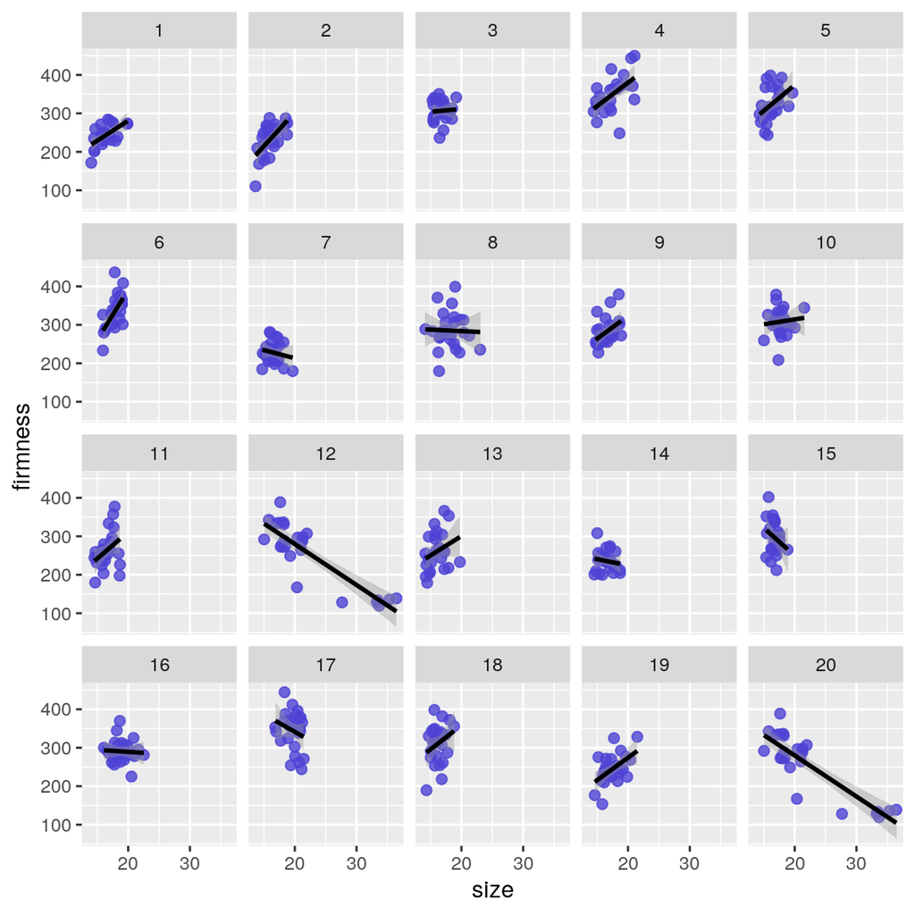

```r
library(ggplot2)
dat <- read.csv("/home/lferrao/Dropbox/classes/Bayesian_UFV/hands_on/blueberry.csv",
                header=TRUE)
ggplot(dat, aes(x = size, y = firmness)) +
  geom_point(size = 2, color = "#4e42d4", alpha = 0.8) +
  facet_wrap("genotypeID", ncol=5) +
  #coord_cartesian(xlim = range(dat$size), ylim = range(dat$firmness)) +
  geom_smooth(method = "lm", se=T, color="black", formula = y ~ x)
```

**Preliminary Conclusions**

### Postulate a Bayesian Regression

$$y_i = \beta_0 + X_i\beta + e_i$$

- We can use the coefficients from a fitted regression model to help study to what degree changes in one variable are associated with changes in another.
- **Important:** Simple Regression model serves as a didactic example that is sufficient to demonstrate simple regression, but it performs a statistical error by ignoring the *within-genotype* dependency in this example.

$$firmness_i \sim N(\beta_0+\beta_1\ size_i, \ \sigma^2)$$

### Fit the Model

- `Stan` is available through a variety of interfaces including `rstan` in `R` and `PyStan` in `Python`.
- R package `rstanarm`.
- [Reference for the R package](https://mc-stan.org/rstanarm/reference/rstanarm-package.html).

**Step 1. Specify the model**

- `stan_glm` function
- Specifies the outcome and predictors in the familiar `lm` formula syntax
- An intercept is included by default.
- Assumes that the likelihood is normal (Gaussian) with an identity link function
- All parameters in a Bayesian modelneed prior distributions
  - Uninformative priors place equal or nearly equal prior weight on all possible values of a parameter.
  - Weakly informative priors provide some information on the relative a priori plausibility of the possible parameter values (help stabilize computations) **default of the package**
  - Informative prior, when we have a lot of prior knowledge to bring to a problem.

**Step 2. Estimate the model parameters**

- Estimate the model parameters.
- By default, `rstanarm` uses 4 Markov chains (`chains`) with 2000 iterations (`iter`) each, half of which are discarded as “warm-up”.
- For situations in which the estimation algorithm does not converge due to an insufficient number of samples, it may be necessary to draw more samples by increasing the iter argument.

**Step 3. Explore the posterior**

- Assess the fit of the model to the data, we can compare the observed data to datasets simulated according to our assumed data generating process and the posterior draws of the model parameters.
- `pp_check` function.
- `bayesplot` R package is an extensive library of plotting functions for use after fitting Bayesian models

#### Weakly informative priors

```r
library("rstanarm")
library("ggplot2")
library("broom")
library("bayesplot")


# Run model 1 with stan_glm
SingleLevelModel <- stan_glm(firmness ~ size,  # Similar notation to lm()
                             chains = 4,       # Number of MCMC chains
                             iter = 2000,      # Number of MCMC steps
                             data = dat)

# View summary of priors used
prior_summary(SingleLevelModel)

# Summary of the data
summary(SingleLevelModel)

# Plot the posterior
# posterior <- as.array(SingleLevelModel)
# mcmc_areas(
#   posterior,
#   pars = c("sigma", "size"),
#   prob = 0.8, # 80% intervals
#   prob_outer = 0.99, # 99%
#   point_est = "mean"
# )
# mcmc_hist(posterior, pars = c("sigma", "size", "(Intercept)"))
```

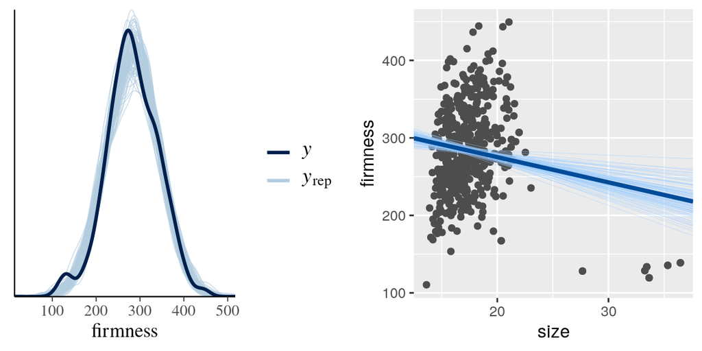

```r
library(gridExtra)
# Explore the posterior
plot1 = pp_check(SingleLevelModel, nreps = 100) + xlab("firmness")

# model’s prediction
posterior1 <- as.matrix(SingleLevelModel)
means1 <- colMeans(posterior1)
betas <- posterior1[sample(nrow(posterior1), 100), 1:2]
blues <- color_scheme_get("brightblue")
mod1p1 <- ggplot(dat, aes(x = size, y = firmness)) +
  geom_point(color = "gray30") +
  geom_abline(intercept = betas[, 1], slope = betas[, 2],
              color = blues[[2]], size = 0.15,  alpha = 0.5
  ) +
  geom_abline(intercept = means1[1],
              slope = means1[2],size = 1.25,  color = blues[[6]]
)

# Ploting
grid.arrange(plot1,mod1p1,ncol=2)
```

#### Informative priors

```r
library("rstanarm")
library("ggplot2")
library("broom")
library("bayesplot")

# Run model 1 with stan_glm
SingleLevelModelMod <-  stan_glm(
  firmness ~ size,
  data = dat,
  prior = normal(20, 1, autoscale = FALSE),
  prior_intercept = normal(50, 100, autoscale = FALSE),
  iter = 4000,
  adapt_delta = 0.99
)

# View summary of priors used
prior_summary(SingleLevelModelMod)
# Summary of the data
summary(SingleLevelModelMod)
```

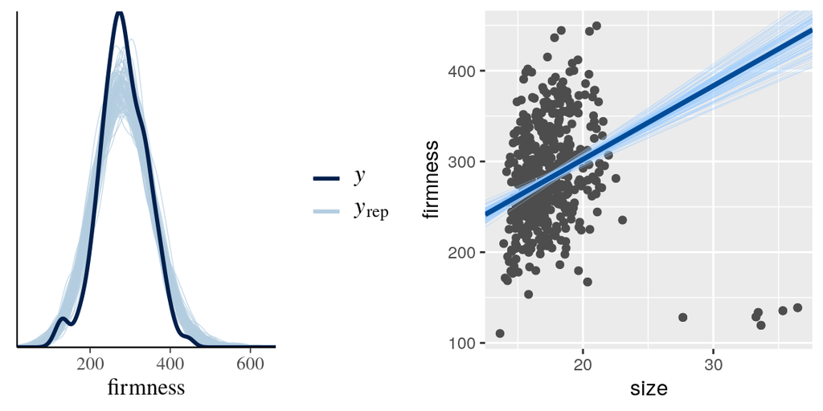

```r
library(gridExtra)
# Explore the posterior
plot1 = pp_check(SingleLevelModelMod, nreps = 100) + xlab("firmness")

# model’s prediction
posterior1 <- as.matrix(SingleLevelModelMod)
means1 <- colMeans(posterior1)
betas <- posterior1[sample(nrow(posterior1), 100), 1:2]
blues <- color_scheme_get("brightblue")
mod1p1 <- ggplot(dat, aes(x = size, y = firmness)) +
  geom_point(color = "gray30") +
  geom_abline(intercept = betas[, 1], slope = betas[, 2],
              color = blues[[2]], size = 0.15,  alpha = 0.5
  ) +
  geom_abline(intercept = means1[1],
              slope = means1[2],size = 1.25,  color = blues[[6]]
)

# Ploting
grid.arrange(plot1,mod1p1,ncol=2)
```

## Interpretation

- By checking the posterior predictive checks: For models that fit the data well, this type of plot will show that the draws from the posterior predictive distribution (thin light lines) and the observed data (thick dark line) have similar distributions.
- In this case, it looks like the model does reasonably well.

**Parameters**

[output not shown]

- **Point estimates**: A point estimate is a single value, most often a measure of central tendency (e.g., mean, median), chosen to summarize a posterior distribution. In contrast to the maximum likelihood approach, in which the point estimate (the mode) is the focus, in the Bayesian framework we are interested in the entire posterior distribution.
- **Posterior intervals (PI) and posterior standard deviation (SD)**: range of the model parameters in probabilistic terms

### Diagnostic

- **Trace plot:** shows the history of a parameter value across iterations of the chain. It is often the best thing for diagnosing common problems. Typically we look for three aspects in these trace plots:
  1. *Stationarity* refers to the path of each chain staying within the same high-probability portion of the posterior distribution. Notice that these traces, for example, all stick around a very stable central tendency, the center of gravity of each dimension of the posterior.
  2. *Good mixing* means that the chain rapidly explores the full region. It doesn’t slowly wander, but rather rapidly zig-zags around.
  3. *Convergence* means that multiple, independent chains stick around the same region of high probability
- **Trace rank plot:** distribution of the ranked samples. The lowest sample gets rank 1. The largest gets the maximum rank (the number of samples across all chains). Then we draw a histogram of these ranks for each individual chain. If the chains are exploring the same space efficiently, the histograms should be similar to one another and largely overlapping.
- **Gelman-Rubin Statistic:** Intuitively, its value is 1.0 if the chains are fully converged, but its value is largerthan 1.0 if there are orphaned or stuck chains. As a heuristic, if the Gelman-Rubin statistic is greater than 1.1 or so, you should worry that perhaps the chains have not converged adequately.
- **Effective sample size Statistic:** divides the actual sample size by the amount of autocorrelation. For example, 600 ESS in a chain of 10000 means that only 600 chains are independent in a total of 10000. Some authors suggest 10000 ESS as a good number.

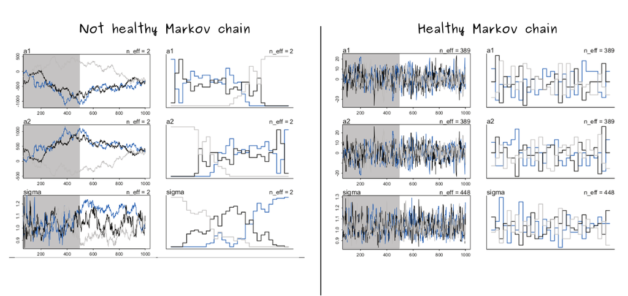

Examples of MCMC from McElreath (2018)

```
launch_shinystan (SingleLevelModel)
```

# Conclusions

- We introduced the R package `rstanarm`, which is a user-friendly tool to fit single-level and more complex Bayesian regression models.
- Bellow a short comparison between both schools. More details [here](https://ocw.mit.edu/courses/mathematics/18-05-introduction-to-probability-and-statistics-spring-2014/readings/MIT18_05S14_Reading20.pdf).

|  | Frequentist | Bayes |
| --- | --- | --- |
| Researchers | R.A.Fisher, Neyman, Pearson and Wald | Bayes, Price and Laplace |
| Probability | never uses or gives the probability of a hypothesis (no prior or posterior) | uses probabilities for both hypotheses and data |
| Inference | depends on the likelihood for both observed and unobserved data | depends on the prior and likelihood of observed data |
| Conclusions | p-values and confidence intervals | posteriori distribution |
| Prior | does not require a prior | requires one to know or construct a ‘subjective prior’ |
| Relevance | dominated statistical practice during the 20th century | dominated statistical practice before the 20th century |
| Computational time | tends to be less computationally intensive | may be computationally intensive due to integration over many parameters |
| Critiques | p-value depends on the exact experimental setup, p-value and significance level are notoriously prone to misinterpretation | subjective prior, philosophical objections to assigning probabilities to hypotheses |
| Defense | It is objective: all statisticians will agree on the p-value, it has been used for over 100 years and we have seen tremendous scientific progress | probability of hypotheses is exactly what we need to make decisions, logically rigorous, easy to communicate a result framed in terms of probabilities of hypothese. |

# References

- Kruschke, J. (2014). Doing Bayesian data analysis: A tutorial with R, JAGS, and Stan. [Link for the book](https://jkkweb.sitehost.iu.edu/index.html)
- Lambert, B. (2018) A Student’s Guide to Bayesian Statistics. [Link for the book](https://ben-lambert.com/about/)
- McElreath, R. (2018). Statistical rethinking: A Bayesian course with examples in R and Stan. Chapman and Hall/CRC. [Link for the book](https://acsess.onlinelibrary.wiley.com/doi/full/10.1002/nse2.20026)
- Muth, C., Oravecz, Z., & Gabry, J. (2018). User-friendly Bayesian regression modeling: A tutorial with rstanarm and shinystan. Quantitative Methods for Psychology, 14(2), 99-119.

[figure not shown]